# Report

### Dataset information:

This dataset is from a 2014 survey that measures attitudes towards mental health and frequency of mental health disorders in the workplace.

#### Content:

This dataset contains the following data:

Timestamp, Age, Gender, Country

state: If you live in the United States, which state or territory do you live in?

self_employed: Are you self-employed?

family_history: Do you have a family history of mental illness?

treatment: Have you sought treatment for a mental health condition?

work_interfere: If you have a mental health condition, do you feel that it interferes with your work?

no_employees: How many employees does your company or organization have?

remote_work: Do you work remotely (outside of an office) at least 50% of the time?

tech_company: Is your employer primarily a tech company/organization?

benefits: Does your employer provide mental health benefits?

care_options: Do you know the options for mental health care your employer provides?

wellness_program: Has your employer ever discussed mental health as part of an employee wellness program?

seek_help: Does your employer provide resources to learn more about mental health issues and how to seek help?

anonymity: Is your anonymity protected if you choose to take advantage of mental health or substance abuse treatment resources?

leave: How easy is it for you to take medical leave for a mental health condition?

mental_health_consequence: Do you think that discussing a mental health issue with your employer would have negative consequences?

phys_health_consequence: Do you think that discussing a physical health issue with your employer would have negative consequences?

coworkers: Would you be willing to discuss a mental health issue with your coworkers?

supervisor: Would you be willing to discuss a mental health issue with your direct supervisor(s)?

mental_health_interview: Would you bring up a mental health issue with a potential employer in an interview?

phys_health_interview: Would you bring up a physical health issue with a potential employer in an interview?

mental_vs_physical: Do you feel that your employer takes mental health as seriously as physical health?

obs_consequence: Have you heard of or observed negative consequences for coworkers with mental health conditions in your workplace?

comments: Any additional notes or comments

### Dataset analysis:

1. By using the 'treatment' and 'work_interfere' columns, find the surveyed who are mentally ill.
- Clean 'Age' columns, parametrize the 'Gender' column.
- Explore dataset for possible insights.

### Hypothesis to be checked:

1. Does family history of mental illness means higher chance of mental illness?
- Are people working in tech companies more prone to mental illness?
- Does gender correlate with mental illness?
- Does Age correlate with Mental Illness?
- Is company size correlated with mental illness?
- How is mental illness health care and benefits approach?
- Work Culture on mental illness.

#### Basic Dataset Info:

- Types: all objects(strings) except for age(int).
- Index(['Timestamp', 'Age', 'Gender', 'Country', 'state', 'self_employed',

  ```
   'family_history', 'treatment', 'work_interfere', 'no_employees',
   'remote_work', 'tech_company', 'benefits', 'care_options',
   'wellness_program', 'seek_help', 'anonymity', 'leave',
   'mental_health_consequence', 'phys_health_consequence', 'coworkers',
   'supervisor', 'mental_health_interview', 'phys_health_interview',
   'mental_vs_physical', 'obs_consequence', 'comments'],
  dtype='object')
  ```

- Timestamp ['2014-08-27 11:29:31' '2014-08-27 11:29:37' '2014-08-27 11:29:44' ... 2015-11-07 12:36:58' '2015-11-30 21:25:06' '2016-02-01 23:04:31']
- Age [ 37 44 32 31 33 35

  ```
      39          42          23          29          36          27
      46          41          34          30          40          38
      50          24          18          28          26          22
      19          25          45          21         -29          43
      56          60          54         329          55 99999999999
      48          20          57          58          47          62
      51          65          49       -1726           5          53
      61           8          11          -1          72]
  ```

- Gender ['Female' 'M' 'Male' 'male' 'female' 'm' 'Male-ish' 'maile' 'Trans-female' 'Cis Female' 'F' 'something kinda male?' 'Cis Male' 'Woman' 'f' 'Mal' 'Male (CIS)' 'queer/she/they' 'non-binary' 'Femake' 'woman' 'Make' 'Nah' 'All' 'Enby' 'fluid' 'Genderqueer' 'Female ' 'Androgyne' 'Agender' 'cis-female/femme' 'Guy (-ish) ^_^' 'male leaning androgynous' 'Male ' 'Man' 'Trans woman' 'msle' 'Neuter' 'Female (trans)' 'queer' 'Female (cis)' 'Mail' 'cis male' 'A little about you' 'Malr' 'p' 'femail' 'Cis Man' 'ostensibly male, unsure what that really means']
- Country ['United States' 'Canada' 'United Kingdom' 'Bulgaria' 'France' 'Portugal' 'Netherlands' 'Switzerland' 'Poland' 'Australia' 'Germany' 'Russia' 'Mexico' 'Brazil' 'Slovenia' 'Costa Rica' 'Austria' 'Ireland' 'India' 'South Africa' 'Italy' 'Sweden' 'Colombia' 'Latvia' 'Romania' 'Belgium' 'New Zealand' 'Zimbabwe' 'Spain' 'Finland' 'Uruguay' 'Israel' 'Bosnia and Herzegovina' 'Hungary' 'Singapore' 'Japan' 'Nigeria' 'Croatia' 'Norway' 'Thailand' 'Denmark' 'Bahamas, The' 'Greece' 'Moldova' 'Georgia' 'China' 'Czech Republic' 'Philippines']
- state ['IL' 'IN' nan 'TX' 'TN' 'MI' 'OH' 'CA' 'CT' 'MD' 'NY' 'NC' 'MA' 'IA' 'PA' 'WA' 'WI' 'UT' 'NM' 'OR' 'FL' 'MN' 'MO' 'AZ' 'CO' 'GA' 'DC' 'NE' 'WV' 'OK' 'KS' 'VA' 'NH' 'KY' 'AL' 'NV' 'NJ' 'SC' 'VT' 'SD' 'ID' 'MS' 'RI' 'WY' 'LA' 'ME']
- self_employed [nan 'Yes' 'No']
- family_history ['No' 'Yes']
- treatment ['Yes' 'No']
- work_interfere ['Often' 'Rarely' 'Never' 'Sometimes' nan]
- no_employees ['6-25' 'More than 1000' '26-100' '100-500' '1-5' '500-1000']
- remote_work ['No' 'Yes']
- tech_company ['Yes' 'No']
- benefits ['Yes' "Don't know" 'No']
- care_options ['Not sure' 'No' 'Yes']
- wellness_program ['No' "Don't know" 'Yes']
- seek_help ['Yes' "Don't know" 'No']
- anonymity ['Yes' "Don't know" 'No']
- leave ['Somewhat easy' "Don't know" 'Somewhat difficult' 'Very difficult' 'Very easy']
- mental_health_consequence ['No' 'Maybe' 'Yes']
- phys_health_consequence ['No' 'Yes' 'Maybe']
- coworkers ['Some of them' 'No' 'Yes']
- supervisor ['Yes' 'No' 'Some of them']
- mental_health_interview ['No' 'Yes' 'Maybe']
- phys_health_interview ['Maybe' 'No' 'Yes']
- mental_vs_physical ['Yes' "Don't know" 'No']
- obs_consequence ['No' 'Yes']

### CLEANING DATASET:

#### Age:

- Checked max() and min().
- Substituted non-sense ages by NaN, range accepted 16-75 (working age).
- Removed symbols (-), considering them misspelling.

#### Gender:

- Parametryzed the genders to 3 (male, female, other):(M, F, O).
- Considered words close to male and female as male and female (fixing possible misspellings).

### MANIPULATING DATASET

##### Assumptions:

1. People that chose 'Yes' for 'treatment' are mental ill;
2. Since the question is: "If you have mental illness...", we can assume people who answered 'work_interfere' differently then 'NaN' are mental ill.

Not considering possible missinterpretations by the person on the 'work_interfere' question, so, included 'Never' as people who are mental ill, but the illness never interfered in work

### EXPLORING DATASET AND VISUALIZING DATA

#### 1. Does family history of mental illness means higher chance of mental illness?

```
The average of ill people that knows about mental illness history in the family is 0.45.
The average of non ill people that knows about mental illness history in the family is 0.16.
```

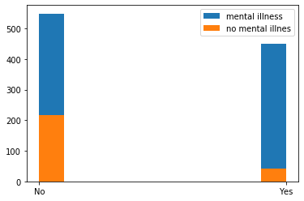

#### Insights:

- Mental illness affects ~80% of the surveyed population.
- People that are mentally ill have 45% chance of knowing about mental illness in family history.
- People who are not mentally ill have 16% chance of knowing about mental illness in family history.

#### Conclusions:

- There is a correlation between mental illness and family history, since people with mental illness have 3x higher chances of having a family history than with people who don't have mental illness;
- We cannot fully infer causality because:
  - mentally ill people might be more concerned about mental illness family history, therefore, learn that information,specially because they're often inquired by doctors about it.
  - people without mental illness might be less concerned about mental illness in the family history, therefore, might not know about it.

##### 2. Are people working in tech companies more prone to mental illness?

```
The average of ill people that work in tech companies is 0.82.
The average of not ill people that work in tech companies is 0.82.
```

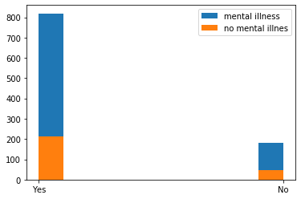

```python
## Disconsidered people who did not know if they worked in tech companies.
```

#### Insights:

- The average of ill people that work in tech companies is 82%.
- The average of not ill people that work in tech companies is also 82%.

#### Conclusions:

- There is no correlation between mental illness and working in tech companies, since about the same amount of people with and without mental illness work in tech companies.

#### 3. Does gender correlate with mental illness?

```
The average of female with mental illness is 0.86.
The average of male with mental illness is 0.77.
The average of other genders with mental illness is 0.95.
```

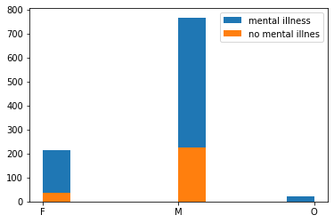

#### Insights:

- The average of female with mental illness is 86%.
- The average of male with mental illness is 77%.
- The average of other genders with mental illness is 95%.

#### Conclusions:

- There is no reasonable correlation between mental illness and gender, since the average difference between genders aren't significant enough and the amount of data on people who identify themselves differently than male and female is also too small.

#### 4. Does Age correlate with Mental Illness?

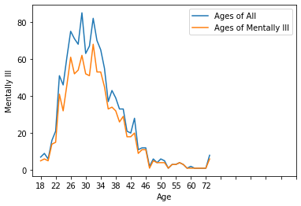

#### Insights:

- Mental illness is more constant on people with ages under 23 and over 40.
- There are apparently some ages between 23-40 where mental illness is also more common.

#### Conclusions:

- There might be a correlation between mental illness and age, being necessary a larger dataset to be more accurate on the assumption, also, it would be interesting to set a research on what mental illness are beeing considered on the survey.

#### 5. Is company size correlated with mental illness?

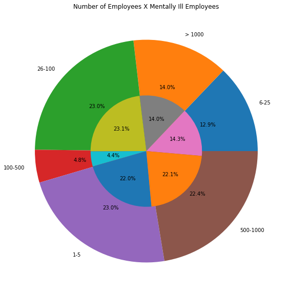

#### Conclusions:

- There is no reasonable correlation between mental illness and company size, since there is no big difference between the percentage of people surveyed in each group of company size, and the percentage of people mentally ill in each group of company size.
- Also, it is important to notice that maybe some people surveyed worked in the same company, specially probable for bigger companies, which would affect the outcome of the study.

#### 6. How is mental illness health care and benefits approach?

##### 6.1 Benefits

```
0.3
```

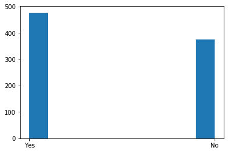

```python
# Companies with benefits x without benefits for the mentally ill.
```

#### 6.2. Care options

- Disclaimer: Despite the question itself being a little missleading (Do you know the options for mental health care your employer provides?), we can assume that Yes = have options, No = don't have options, Not sure = don't know if have options.

```
0.4
```

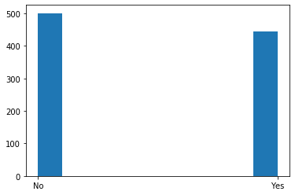

```python
# Companies with health care x without health care for mental illness.
## To analyse our data, we will only rely on the 'Yes' and 'No'.
```

#### 6.3 Since some companies might have care options but not benefits, I took the average:

The average is that at least 50% of the companies offer mental health care and/or benefits.

### Insights:

- Here we notice a lot of 'don't know', and a close enough ammount of 'yes' and 'no', making it hard to take any conclusions on this matter.
- Also, it's important to note that in many countries mental health is included in health benefits in general.
- What we can assume is that at least 30% of the companies don't have benefits for people with mental illness.
- At least 40% of the people surveyed don't have care options for mentally ill in their companies.
- We can infer that 30% of mentally ill people are not informed about health care / benefits in their company.
- People without mental illness are more prone to not knowing about the topics (43%).

### 7. Work Culture on mental illness.

Since mental health care and benefits have finacial consequences to the company, they were treated in the topic below, appart from the company culture. Here we will analyse the social and human conditions on the topic. Also, we are not considering uncertain answers ('don't knows', 'not sures').

To analyse the work culture in companies on mental illness we can analyse the columns:

- wellness_program, seek_help, anonymity, leave, mental_health_consequence, obs_consequence.

For further analysis we can compare the mental_health_consequence with phys_health_consequence.

#### 7.1. Finding relations within the companies adopting best practices and countries

I checked if the country of the company influence on it adopting best practices towards mental illness. The result was USA, but it is also the country with more number of surveyed, so I took the average of each country in the whole table to get a better result.

```
([0, 1, 2, 3, 4, 5, 6], <a list of 7 Text xticklabel objects>)
```

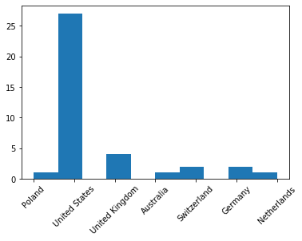

```python
# Histogram without taking the average of total surveyed in each country.
```

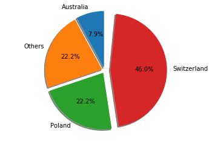

```
38
```

```python
# 7.1.1. Considering the average of surveyed in each country.
```

#### 7.2. Finding relations within the companies adopting best practices and sizes

We can check if the size of the company influence on it adopting best practices towards mental illness. The result was more then 1000 employees, but, again, it's more probable that there are more people working in big companies, so, I took the average of all the people surveyed in each company size.

```
([0, 1, 2, 3, 4, 5], <a list of 6 Text xticklabel objects>)
```

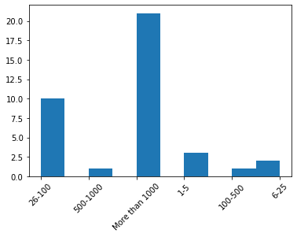

```python
# The result without considering the whole average.
```

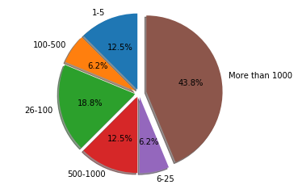

```python
# Considering the amount of people surveyed in each company size as counter weights:
```

### 8. Comments WordCloud

To quickly check the words most used in the Comments section, we can build a wordcloud, and maybe get an ideia of what they are about.

|  | # |
| --- | --- |
| health | 105 |
| mental | 99 |
| work | 43 |
| employer | 36 |
| would | 33 |
| issues | 28 |
| people | 27 |
| know | 25 |
| company | 25 |
| because | 23 |

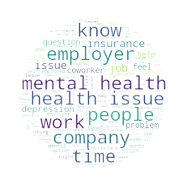

```python
# Wordcloud
```

### Insights:

Some interesting words that can be useful to analyse are words such as 'depression', where we can conclude that part of the people with mental illness in the survey suffer from. 'Time' is also a word that appears a lot and maybe it would be interesting to check why.